# Supplementary Material: Fertility Rates Article

Furthermore, observing the summary measures present in the R output below the graphs, we can see that the mean of the residuals is approximately zero, their variance is approximately one, their skewness coefficient is close to zero and their kurtosis coefficient is close to 3. Thus, both the graphs and the summary statistics suggest that the residuals follow, approximately, the standard normal distribution, which would be necessary for the model to be considered adequate.

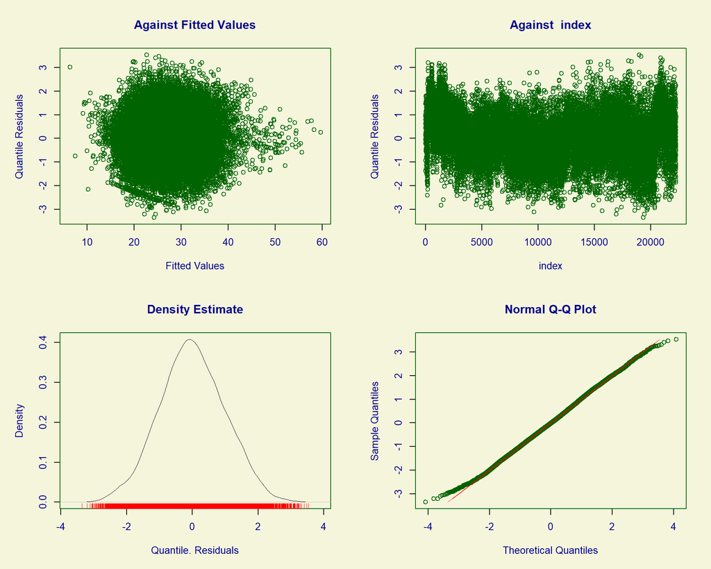

Figure 30: Usual graphs related to the residual analysis of the selected model for the skew t type 4 distribution.

```
##        Summary of the Quantile Residuals
##                            mean   =  0.001643343
##                        variance   =  0.99794
##                coef. of skewness  =  0.04010143
##                coef. of kurtosis  =  2.865816
## Filliben correlation coefficient  =  0.9996984
```

```r
# Residual analysis of the selected model
plot(fit4_st4)
```

An additional check of the model’s adequacy can be done through *worm plots*. In simplified terms, we would expect an adequate model that:

- the yellow points on the graph, which represent the model’s residuals, are as close as possible to the dotted horizontal line at $y = 0$, which represents their approximate expected values;
- 95% of the yellow points are between the elliptical curves on the graph, since they represent an approximate 95% confidence interval (*point-wise*) for the model’s residuals;
- and that the curve fitted to the points on the graph (in red) is as straight as possible and is as close as possible to the horizontal line at $y = 0$.

As we can see, the graph shown in the figure below does indeed present points that are outside the graph’s elliptical curves, which reveal that the fit was not as perfect as one would like it to be. However, as the deviations do not appear to be so numerous, and as other distributions resulted in adjustments that were extremely inferior to what was obtained through the asymmetric t distribution of type 4, we chose to consider the model found as adequate (as far as possible).

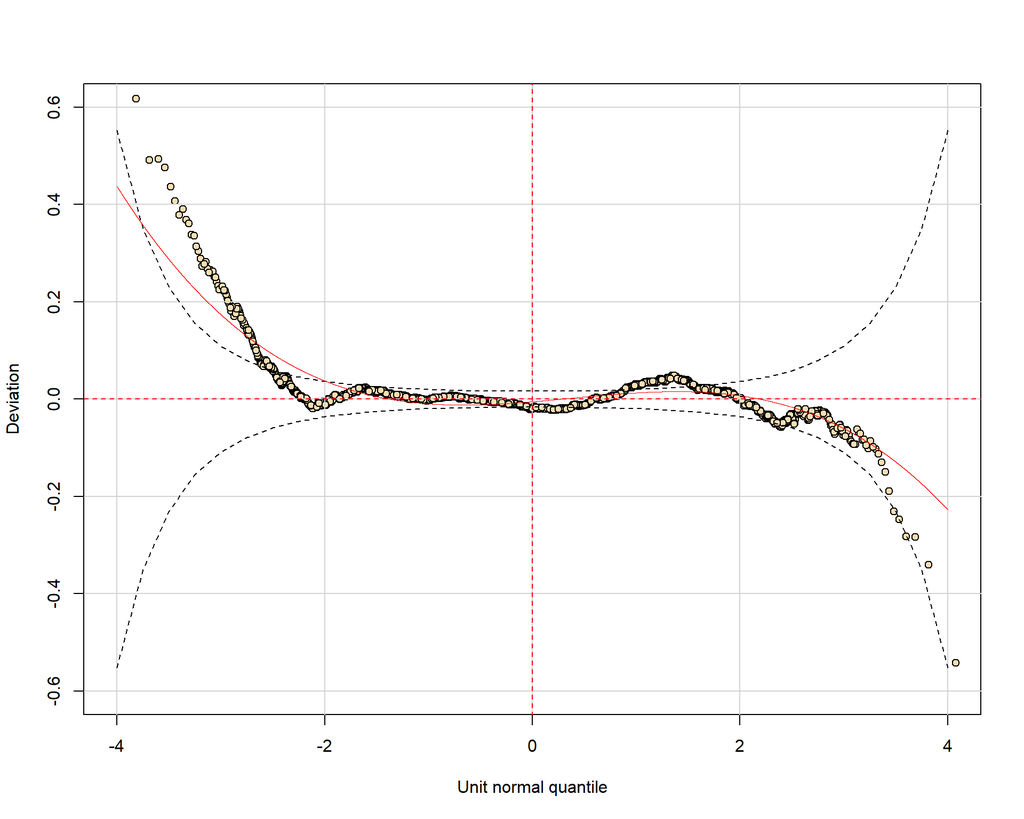

Figure 31: Worm plot of the selected model for the skew t type 4 distribution.

```r
wp(fit4_st4, ylim.all = 0.6)
```

### For the ZAGA distribution

```r
# Adjusting the full model
fit1_zaga <- gamlss(
  tx_fecundidade_menor_20 ~ random(ano) + (pandemia + cobertura_ab + idhm) * (pandemia + cobertura_ab + idhm),
  data = df_indicadores,
  family = ZAGA(),
  sigma.formula = ~ random(ano) + (pandemia + cobertura_ab + idhm) * (pandemia + cobertura_ab + idhm),
  nu.formula = ~ random(ano) + (pandemia + cobertura_ab + idhm) * (pandemia + cobertura_ab + idhm),
  control = gamlss.control(n.cyc = 500)
)
sumario_fit1_zaga <- summary(fit1_zaga, save = TRUE)

# Utilizing the two strategies described in the book "Flexible Regression and Smoothing: Using GAMLSS in R", page 397, to get the best models for each parameter
## Adjusting a model with only the intercept for mu and considering sigma and nu as constants
fit2_zaga <- gamlss(
  tx_fecundidade_menor_20 ~ 1,
  data = df_indicadores,
  family = ZAGA,
  control = gamlss.control(n.cyc = 500)
)

## Strategy 1:
### Starting from the simplest model and utilizing the forward stepwise method to find the model with the lowest AIC for each parameter
### Obs.: in this strategy, different variables can be selected for each parameter's model
fit3_zaga <- stepGAICAll.A(
  fit2_zaga,
  scope = list(lower =~ 1, upper =  ~ random(ano) + (pandemia + cobertura_ab + idhm) * (pandemia + cobertura_ab + idhm))
)
sumario_fit3_zaga <- summary(fit3_zaga, save = TRUE)

## Strategy 2:
### This strategy forces all os the models to select the same variables subsets
fit4_zaga <- stepGAICAll.B(
  fit2_zaga,
  scope = list(lower =~ 1, upper =  ~ random(ano) + (pandemia + cobertura_ab + idhm) * (pandemia + cobertura_ab + idhm))
)
sumario_fit4_zaga <- summary(fit4_zaga, save = TRUE)

## Adjusting a third model with only the significant terms for mu
fit5_zaga <- gamlss(
  tx_fecundidade_menor_20 ~ random(ano) + pandemia + cobertura_ab + idhm + pandemia*idhm + cobertura_ab*idhm,
  data = df_indicadores,
  family = ZAGA(),
  sigma.formula = ~ random(ano) + (pandemia + cobertura_ab + idhm) * (pandemia + cobertura_ab + idhm),
  nu.formula = ~ random(ano) + (pandemia + cobertura_ab + idhm) * (pandemia + cobertura_ab + idhm),
  tau.formula = ~ random(ano) + (pandemia + cobertura_ab + idhm) * (pandemia + cobertura_ab + idhm),
  control = gamlss.control(n.cyc = 500)
)
sumario_fit5_zaga <- summary(fit5_zaga, save = TRUE)
```

The tables below show the estimates, standard errors, and significance tests for the models adjusted for $\mu$ in each of the four settings, as well as the additional random intercept terms for each year in each model. The applications of the GLRT and a comparison between the AIC of the three models can be seen below the tables.

- For the complete model:

```r
kable(
  round(sumario_fit1_zaga$coef.table, 4)[1:7, ],
  align = "cccc",
  caption = "Measures related to the estimated coefficients for the location parameter in the full model (for the ZAGA distribution)."
)
```

Table 16: Measures related to the estimated coefficients for the location parameter in the full model (for the ZAGA distribution).

|  | Estimate | Std. Error | t value | Pr(>\|t\|) |
| --- | --- | --- | --- | --- |
| (Intercept) | 7.3810 | 0.1608 | 45.9154 | 0.0000 |
| pandemiaduring | 0.1525 | 0.0691 | 2.2074 | 0.0273 |
| cobertura_ab | -0.0231 | 0.0017 | -13.7433 | 0.0000 |
| idhm | -5.6596 | 0.2214 | -25.5640 | 0.0000 |
| pandemiaduring:cobertura_ab | 0.0003 | 0.0003 | 1.0609 | 0.2888 |
| pandemiaduring:idhm | -0.4239 | 0.0785 | -5.3999 | 0.0000 |
| cobertura_ab:idhm | 0.0306 | 0.0023 | 13.0669 | 0.0000 |

```r
getSmo(fit1_zaga)$coef
```

```
##         2018         2019         2020         2021
##  0.028981948 -0.029035521 -0.002536271  0.002524325
```

- For the reduced model chosen by the first variable selection strategy:

```r
kable(
  round(sumario_fit3_zaga$coef.table, 4)[1:4, ],
  align = "cccc",
  caption = "Measures related to the estimated coefficients for the location parameter in the first reduced model (for the ZAGA distribution)."
)
```

Table 17: Measures related to the estimated coefficients for the location parameter in the first reduced model (for the ZAGA distribution).

|  | Estimate | Std. Error | t value | Pr(>\|t\|) |
| --- | --- | --- | --- | --- |
| (Intercept) | 7.4360 | 0.1594 | 46.6467 | 0 |
| idhm | -5.8374 | 0.2204 | -26.4832 | 0 |
| cobertura_ab | -0.0227 | 0.0017 | -13.4841 | 0 |
| idhm:cobertura_ab | 0.0303 | 0.0024 | 12.8729 | 0 |

```r
getSmo(fit3_zaga)$coef
```

```
##        2018        2019        2020        2021
##  0.07740670  0.01684515 -0.05079312 -0.04396797
```

- For the reduced model chosen by the second variable selection strategy:

```r
kable(
  round(sumario_fit4_zaga$coef.table, 4)[1:6, ],
  align = "cccc",
  caption = "Measures related to the estimated coefficients for the location parameter in the second reduced model (for the ZAGA distribution)."
)
```

Table 18: Measures related to the estimated coefficients for the location parameter in the second reduced model (for the ZAGA distribution).

|  | Estimate | Std. Error | t value | Pr(>\|t\|) |
| --- | --- | --- | --- | --- |
| (Intercept) | 7.3653 | 0.1596 | 46.1623 | 0 |
| idhm | -5.6552 | 0.2210 | -25.5898 | 0 |
| cobertura_ab | -0.0230 | 0.0017 | -13.7355 | 0 |
| pandemiaduring | 0.2049 | 0.0474 | 4.3199 | 0 |
| idhm:cobertura_ab | 0.0307 | 0.0023 | 13.1290 | 0 |
| idhm:pandemiaduring | -0.4566 | 0.0716 | -6.3724 | 0 |

```r
getSmo(fit4_zaga)$coef
```

```
##         2018         2019         2020         2021
##  0.028938741 -0.028995204 -0.002883041  0.002868946
```

- For the reduced model chosen by the third variable selection strategy:

```r
kable(
  round(sumario_fit5_zaga$coef.table, 4)[1:6, ],
  align = "cccc",
  caption = "Measures related to the estimated coefficients for the location parameter in the third reduced model (for the ZAGA distribution)."
)
```

Table 19: Measures related to the estimated coefficients for the location parameter in the third reduced model (for the ZAGA distribution).

|  | Estimate | Std. Error | t value | Pr(>\|t\|) |
| --- | --- | --- | --- | --- |
| (Intercept) | 7.3631 | 0.1596 | 46.1481 | 0 |
| pandemiaduring | 0.2055 | 0.0475 | 4.3315 | 0 |
| cobertura_ab | -0.0230 | 0.0017 | -13.7147 | 0 |
| idhm | -5.6520 | 0.2210 | -25.5786 | 0 |
| pandemiaduring:idhm | -0.4576 | 0.0717 | -6.3826 | 0 |
| cobertura_ab:idhm | 0.0307 | 0.0023 | 13.1089 | 0 |

```r
getSmo(fit5_zaga)$coef
```

```
##         2018         2019         2020         2021
##  0.028938785 -0.028995235 -0.002907182  0.002895095
```

- GLRT applications and comparison between AICs:

```r
# Verificando, pelo TRVG, se os modelos reduzidos são melhores que o modelo completo
LR.test(fit3_zaga, fit1_zaga)  # The model selected by the first strategy (fit3_zaga) ISN'T better than the full model
```

```
##  Likelihood Ratio Test for nested GAMLSS models.
##  (No check whether the models are nested is performed).
##
##        Null model: deviance= 167837.1 with  19.68155 deg. of freedom
##  Altenative model: deviance= 167793.9 with  25.74238 deg. of freedom
##
##  LRT = 43.22143 with 6.060835 deg. of freedom and p-value= 0.0000001127193
```

```r
LR.test(fit4_zaga, fit1_zaga) # The model selected by the second strategy (fit4_zaga) IS better than the full model
```

```
##  Likelihood Ratio Test for nested GAMLSS models.
##  (No check whether the models are nested is performed).
##
##        Null model: deviance= 167796.6 with  22.78337 deg. of freedom
##  Altenative model: deviance= 167793.9 with  25.74238 deg. of freedom
##
##  LRT = 2.7297 with 2.959016 deg. of freedom and p-value= 0.4278576
```

```r
LR.test(fit5_zaga, fit1_zaga) # The model selected by the third strategy (fit5_zaga) IS better than the full model
```

```
##  Likelihood Ratio Test for nested GAMLSS models.
##  (No check whether the models are nested is performed).
##
##        Null model: deviance= 167795 with  24.7419 deg. of freedom
##  Altenative model: deviance= 167793.9 with  25.74238 deg. of freedom
##
##  LRT = 1.11138 with 1.000488 deg. of freedom and p-value= 0.2919317
```